# Python and Jupyter Notebooks Tutorial

## Intro To Astronomy 2024, Week 1

#### Written by [Chetan Chawla](https://sites.google.com/view/chetanchawla)

### In this tutorial, you will:

- learn in Layman terms about Python and its uses
- learn about text editors, Jupyter Notebooks and online notebook platforms like Colab and JupyterLab
- work on the Software Data Carpentry for Python (Which is the main aim for this)

## 1. What is Python?

[figure not shown]

Python is a very-high level programming language that can be used for several computing tasks. These programs are written with a particular **syntax**. For example, to write or print my name on the screen, we can use the command `print('Chetan')`, written with the keyword print, the brackets (parenthesis) and the inverted commas as syntax. Python's syntax is verbose and simple, making it possible to write complex codes easily. **Statement grouping** in Python is done using indentation and commands are separated by new lines.

It is also an Object Oriented Programming Language (OOPS), so we can define certain Python objects in the code which takes on a set of properties making it reproducible and structured.

Python is an **interpreted** language, which is to say that a set of Python commands written together in a file to be executed as a program, or a Python script, is taken one line at a time, converted into code identifiable by our computer (machine code), and executed before going on to the next line in a top to bottom fashion.

💡What then is the **difference between Unix scripts and Python scripts**? Unix Shell scripts are best at moving around files and changing text data due to their higher speeds as they interact directly with the Operating System. However, Python adds in several layers of abstractions, making it possible to write very complex scripts possible and easy. It is a very powerful language. It is also dynamically-typed, meaning that it designates the data types and structures automatically, without the need for us to tell them explicitly. All this makes Python program execution a bit slower than the same program in Unix, but far more functionally complex and diverse, yet programmatically easy.

😄Fun fact - Python is named after Monty Python's Flying Circus

## 2. Installation - Anaconda Distribution of Python

It is recommended to install the Anaconda distribution.

[Anaconda | Individual Edition](https://www.anaconda.com/products/individual-b)

This guide also shows how to install Anaconda or Mini Conda distribution for Python -

```python
%%html
<div style="text-align:center;">
<iframe src="https://docs.conda.io/projects/conda/en/latest/user-guide/install/" width="960" height="540"></iframe>
</div>
```

[interactive chart not shown]

💡*Note: If you want to have Python without Anaconda, please make sure that you install Python 3.x correctly and are able to access it using the Terminal (or command prompt for Windows). Also, install the libraries as and when they are required using [pip](https://www.notion.so/Python-and-Jupyter-Notebooks-Tutorial-Intro-To-Astro-2021-4333519160a44f998f4fde8b77eea607).*

### 2.1 Python Functions, Modules and Packages

Python in itself has several pre-defined **functions** which can be used to attain several tasks (functions are blocks of commands which take in certain inputs, do a particular task in the code and returns the output - for example, `print()` is a function which takes in the argument or input in its parenthesis and prints the given input to the screen).

Several functions can be grouped together to provide a complete set of functions to solve a task in a particular domain. These collections of python functions in a single python file are called **modules**. Several modules taken together are called **packages**.

There are several in-built Python modules as well. However, to expand the set of functionalities, we can create and use 3rd-party packages and modules in Python, such as working on tabular data like using the Pandas package, working on numerical data and matrices using numpy, or plotting mathematical data using matplotlib.

### 2.2 Anaconda Distribution

Anaconda packs several of these packages into one **distribution** so that we don't have to install all of them separately. This makes it easier for us to do astronomical data analysis.

Further, we can make isolated workspaces of collections of these libraries and different Python versions as per our requirements in different projects using Anaconda. These are called virtual (conda) **environments**.

## 3. Basic Python Commands using the Terminal

Open the Terminal / Command Prompt for Windows. If you have installed Anaconda correctly, you should see `(base)` in front of the current line.

[figure not shown]

Writing `python` should start the python interpreter. Here you can see the version of your Python and can write and execute commands one by one. The Python version should be 3.x

[figure not shown]

Let us try doing an arithmetic operation like `2+3` and printing our names using `print("Chetan")`.

[figure not shown]

Now let us try by importing a module named `os` using `import os`. A module is a collection of several functions that do different tasks in a particular domain. Importing a module means we can use the functions of this module in our code as per requirement

[figure not shown]

The module `os` is supposed to contain several functions to communicate with the operating system using python. For example, if we wanted to get our current working directory or the folder, we can use the function `os.getcwd()`.

[figure not shown]

We can also install other new modules/packages. These are often distributed by pip. We first have to quit Python using `exit()`. Then to install new modules, we have to use the command `pip install libraryName`. For example, I have tried installing the library `numpy`. Since this was already included in the Anaconda distribution, it says that the requirement is already satisfied.

[figure not shown]

## 4. Text Editors and Scripts

To write several commands as one and run them together as a script, we can use any text editor. One such minimal text editor is [**Sublime**](https://www.sublimetext.com/download). It can also be used to directly trigger and debug python scripts. Further, it colour codes the syntax according to the programming language you are using, which makes the code easier to read for us.

For now, we will use it as a simple text editor to write and save the script. You can use any text editor such as the TextEdit and Notepad too. We will write a simple script that adds, subtracts, divides and multiplies two numbers and prints the results. Here we use two variables `a` and `b` to store two integers we want to do arithmetic operations on (**variables** are spaces in computer's memory which are named for reference and store some values of a particular datatype like integers, decimals or floats, strings, etc). After writing the program, save the file with a '*.py'* extension. This Python script is executed using `python*script_name.py*` from the terminal if we are in the same folder as the folder this script is placed in. (Otherwise, we can use `python*path_to_script/script_name.py*`). As you can see below, all the statements in the script were executed together, one statement at a time.

[figure not shown]

## 5. Jupyter Notebooks

What if we wanted to write small portions of our codes and execute them in chunks, include some text, headings and equations to explain the code, and see our graphs and plots in a more interactive way? We can use Interactive Python notebooks called **Jupyter Notebooks** (earlier known as IPython notebooks).

To **open** Jupyter Notebooks, let us go into the terminal and type `jupyter notebook` (Note: if you did not install Anaconda distribution, you will have to install the library separately first using `pip install jupyter`) Jupyter notebook opens up the folder structure of your current folder and its subfolders in a browser tab. This runs only locally on your computer and does not require an internet connection.

[figure not shown]

We can create a new notebook using this or open an existing one. So let us try opening a new one.

[figure not shown]

On the top, we have the notebook name, which is Untitled by default. The default first line in a new notebook is a code cell. You can write some code in this and execute this cell independently. Let us change the name of the notebook and copy paste the code we used in the script in this cell. To execute a cell, we can either press the button `Run` or use the shortcut Cmd+Enter (Ctrl+Enter in Windows or Linux). Alternatively, we can use the shortcut Shift+Enter to execute the current cell and move to the next cell. If no next cell exists, it creates a new cell. The `ln [ ]` on the left indicates the line execution number and is empty for the cells which haven't been executed yet, progressively adding up for each execution.

```python
a=7
b=3
print('Sum= ', a+b)
print('Difference= ', a-b)
print('Division= ', a/b)
print('Multiplication= ',a*b)
```

```
Sum=  10
Difference=  4
Division=  2.3333333333333335
Multiplication=  21
```

Here, we can see the output of the current cell. These variables can be used throughout the notebook in any cell (unless they are updated with some other values). Let's say I want to calculate the remainder when dividing the variable `a` by `b`, I can do so in a new cell using `a%b` like:

```python
#This is a comment
'''
THis is also a comment
These are ignored by Python; They are not executed
'''

#Calculating remainder here
print('Remainder= ', a%b)
```

```
Remainder=  1
```

If you don't know what a particular function does, you can use `?function_name` to check its **documentation** directly in Jupyter like-

```python
#Importing the library numpy and aliasing as np
import numpy as np
?np.loadtxt
```

Some more useful things in Jupyter -

- Arrow buttons can be used to navigate between cells
- Cell type can be converted to Markdown to write text and headings
- Headings in markdown are written using # in front of the text (with a space). Smaller and smaller headings can be written using multiple #s (# heading, ## sub-heading, ### sub-sub-heading, etc.)
- We can check out the complete list of shortcuts using Help
- A beginner guide to Jupyter can be found on their documentation [here](https://jupyter-notebook-beginner-guide.readthedocs.io/en/latest/what_is_jupyter.html)

## 6. The Power of Python

We discussed that Python can be powerful. But exactly how powerful can it be? Let us see an example where Python reads 20,000 rows of data with 97 different columns in a very short amount of time. This is done using the package Pandas. Similarly, we use a package called Matplotlib to visualise this data with ease.

### All these topics will be discussed in detail in the coming weeks, this is just to show that Python can be used to achieve very complex tasks in very few lines of code and very swiftly

Here, we are loading positional data of 20,000 stars from a CSV table that consists of Gaia (ESA's space telescope) data for the closest stars. We are then showing all the stars as per their positional coordinates RA and Dec (Right Ascension and Declination) as follows

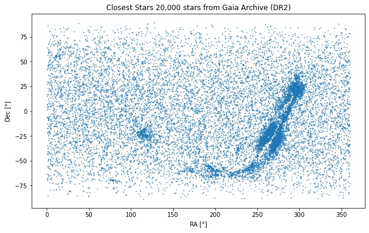

```python
# Importing the libraries (Pandas and Matplotlib)
import pandas as pd
import matplotlib.pyplot as plt

# Reading 20,000 Rows*97 columns of Data- Closest 20k stars from Gaia Archive (DR2)
stellar=pd.read_csv('data/closest20kstars.csv')

# Creating a matplotlib (pyplot) figure
fig = plt.figure(figsize = [10,6])

# Plotting the scatter graph with RA on x-axis and Dec on y-axis. alpha tells the opacity, s is the size
plt.scatter(stellar['ra'], stellar['dec'], alpha=0.8, s=0.7)
# Adding labels and a title for the figure
plt.xlabel('RA [$\degree$]')
plt.ylabel('Dec [$\degree$]')
plt.title('Closest Stars 20,000 stars from Gaia Archive (DR2)')
```

We can use the magic command below to also play with the 3D graph!

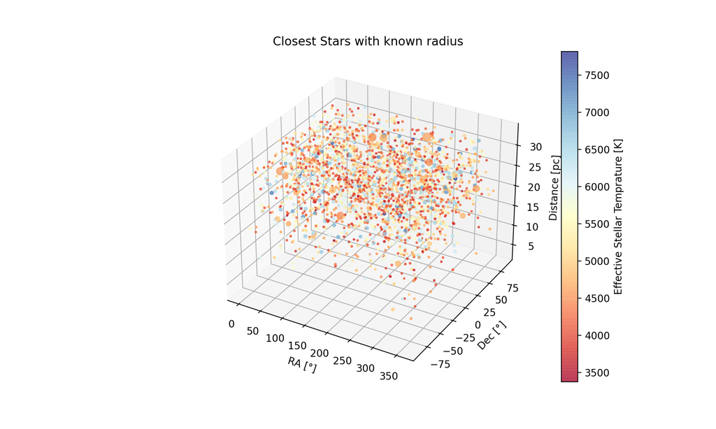

```python
# Taking out only those stars whose radius is known in the data
stellar_trim=stellar[(stellar['radius_val'].notnull())]

# The magic command below can be used for interactive 3D plots. Uncomment to visualize the plot in a better way.
%matplotlib notebook

# Creating a matplotlib (pyplot) figure
fig = plt.figure(figsize = (10, 6))
# Define 3D axes
ax = plt.axes(projection ="3d")
# Plot the scatter graph using RA, Dec and distance. A colormap of Red-Yellow-Blue scale is used
# with sizes s given by stellar radii, color c given by stellar effective temperature. Opacity is set by alpha
scatter_plot=ax.scatter3D(stellar_trim['ra'], stellar_trim['dec'], stellar_trim['s_dist'],
              s=stellar_trim['radius_val']*5, c=stellar_trim['teff_val'], cmap='RdYlBu', alpha=0.7)

#Setting labels, title and a colorbar for the figure
ax.set_xlabel('RA [$\degree$]')
ax.set_ylabel('Dec [$\degree$]')
ax.set_zlabel('Distance [pc]')
plt.title('Closest Stars with known radius')
fig.colorbar(scatter_plot, label="Effective Stellar Temprature [K]")
```

## 7. Google Colab and JupyterLab

We can also make use of Jupyter Notebooks on the Cloud without installing anything on our local computers. For this, we can use the Google Colab or JupyterLab, which are both free services (upto certain computation and storage limits). We can also store our files for processing on these platforms. You will need a Google account to access and save our notebooks in Colab. We can also check out their [guides](https://colab.research.google.com/notebooks/intro.ipynb#scrollTo=-Rh3-Vt9Nev9) for Google Colab to learn more about it.

[Google Colaboratory](https://colab.research.google.com/)

Jupyter Labs is a similar solution provided by Project Jupyter.

[Project Jupyter](https://jupyter.org/try)

## 8. Software Data Carpentry for Python and Assignment

Go through the Software Carpentry Tutorial for Programming with Python. The tutorial is specifically focussed on the scientific task of Data Analysis with Python and is starts from the very scratch of Python.

**Link: https://swcarpentry.github.io/python-novice-inflammation/**

```python
%%html
<div style="text-align:center;">
<iframe src="https://swcarpentry.github.io/python-novice-inflammation/" width="960" height="540"></iframe>
</div>
```

[interactive chart not shown]

# **Assignment: Save each of the plots that you create with the tutorial. You can share this on Discord!**

## 9. Bonus

`import this` opens up the Zen of Python. It is a collection of 19 "guiding principles" for writing computer programs that influence the design of the Python programming language [Source: [Wiki](https://en.wikipedia.org/wiki/Zen_of_Python)].

```python
import this
```

[output not shown]